# Exploratory Data Analysis of Aggregate Enrollments

Andrew Landgraf

First, pull in the data created by Zhou, which was downloaded from [here](http://www.cps.edu/SchoolData/Pages/SchoolData.aspx). Also, look at the structure of the data.

```r
# setwd('~/../github/predicting_student_enrollment/')
load("enrollment_all_data.Rdata")
# load('enrollment_data.Rdata')
str(output)
```

```
##  chr [1:512, 1:19, 1:9] "610212" "609789" "610083" "609796" ...
##  - attr(*, "dimnames")=List of 3
##   ..$ : chr [1:512] "1" "2" "3" "4" ...
##   ..$ : chr [1:19] "School_ID" "School_Name" "School_Type" "PE" ...
##   ..$ : NULL
```

```r
head(output[, , 1])
```

```
##   School_ID School_Name   School_Type PE    PK    K     G01   G02   G03
## 1 "610212"  "Albany Park" "0"         "  0" "  0" "  0" "  0" "  0" "  0"
## 2 "609789"  "Barry"       "0"         "  0" "148" "117" "119" " 95" "115"
## 3 "610083"  "Beard"       "0"         "  0" " 67" " 28" " 30" " 23" " 25"
## 4 "609796"  "Beaubien"    "0"         "  0" " 55" " 75" " 96" "119" "107"
## 5 "609798"  "Belding"     "0"         "  0" " 36" " 55" " 61" " 40" " 53"
## 7 "609810"  "Bridge"      "0"         "  0" "  0" " 56" " 79" " 78" " 80"
##   G04   G05   G06   G07   G08   G09    G10   G11    G12    Total
## 1 "  0" "  0" "  0" "136" "129" "   0" "  0" "   0" "   0" " 265"
## 2 "103" " 93" " 91" "  0" "  0" "   0" "  0" "   0" "   0" " 881"
## 3 "  0" "  0" "  0" "  0" "  0" "   0" "  0" "   0" "   0" " 173"
## 4 "123" "117" "116" "111" "111" "   0" "  0" "   0" "   0" "1030"
## 5 " 65" " 50" " 55" " 51" " 58" "   0" "  0" "   0" "   0" " 524"
## 7 " 77" " 82" " 97" " 77" " 91" "   0" "  0" "   0" "   0" " 717"
```

Transform the data into a data frame, with one row per school and year.

```r
library(plyr)
options(stringsAsFactors = FALSE)
dat = adply(output, 3, rbind.fill)
str(dat)
```

```
## 'data.frame':    4608 obs. of  20 variables:
##  $ X1         : Factor w/ 9 levels "1","2","3","4",..: 1 1 1 1 1 1 1 1 1 1 ...
##  $ School_ID  : chr  "610212" "609789" "610083" "609796" ...
##  $ School_Name: chr  "Albany Park" "Barry" "Beard" "Beaubien" ...
##  $ School_Type: chr  "0" "0" "0" "0" ...
##  $ PE         : chr  "  0" "  0" "  0" "  0" ...
##  $ PK         : chr  "  0" "148" " 67" " 55" ...
##  $ K          : chr  "  0" "117" " 28" " 75" ...
##  $ G01        : chr  "  0" "119" " 30" " 96" ...
##  $ G02        : chr  "  0" " 95" " 23" "119" ...
##  $ G03        : chr  "  0" "115" " 25" "107" ...
##  $ G04        : chr  "  0" "103" "  0" "123" ...
##  $ G05        : chr  "  0" " 93" "  0" "117" ...
##  $ G06        : chr  "  0" " 91" "  0" "116" ...
##  $ G07        : chr  "136" "  0" "  0" "111" ...
##  $ G08        : chr  "129" "  0" "  0" "111" ...
##  $ G09        : chr  "   0" "   0" "   0" "   0" ...
##  $ G10        : chr  "  0" "  0" "  0" "  0" ...
##  $ G11        : chr  "   0" "   0" "   0" "   0" ...
##  $ G12        : chr  "   0" "   0" "   0" "   0" ...
##  $ Total      : chr  " 265" " 881" " 173" "1030" ...
```

Edit the variables types and add a `Year` variable.

```r
dat$Year = as.numeric(dat$X1) + 2005
dat$School_ID = as.numeric(dat$School_ID)
# dat$School_Name = as.factor(dat$School_Name)
dat$School_Type = as.factor(dat$School_Type)

for (col in 5:20) {
    dat[, col] = as.numeric(dat[, col])
}
```

Add the total enrollments of the school for the first year of the data set (2006) in order to make comparisons.

```r
dat2006 = subset(dat, Year == 2006, select = c("School_ID", "Total"))
colnames(dat2006)[2] = "Total_2006"
dat = merge(dat, dat2006)
```

The total enrollments should match the sum of the enrollments by grade, for each school and year.

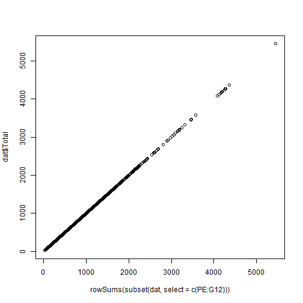

```r
plot(rowSums(subset(dat, select = c(PE:G12))), dat$Total)
```

```r
max(abs(rowSums(subset(dat, select = c(PE:G12))) - dat$Total))
```

```
## [1] 0
```

Plot the total enrollments by year of each school. Also plot the ratio of the yearly enrollments and the enrollments in the first year (2006). These are broken up by charter and non-charter schools.

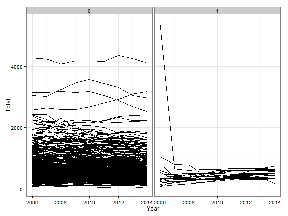

```r
library(ggplot2)
ggplot(subset(dat), aes(Year, Total, group = School_ID)) + facet_wrap(~School_Type) +
    geom_line()
```

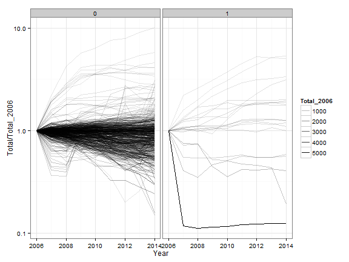

```r
ggplot(subset(dat), aes(Year, Total/Total_2006, group = School_ID)) + geom_line(aes(alpha = Total_2006)) +
    facet_wrap(~School_Type) + scale_y_log10()
```

Summarize the schools by their average yearly enrollment and the SD of the yearly enrollment. I did this to find a school that consistently has lots of students.

```r
head(ddply(dat, .(School_ID), summarize, mean = mean(Total), sd = sd(Total)))
```

```
##   School_ID   mean      sd
## 1     4e+05  448.1   76.00
## 2     4e+05  532.3   50.12
## 3     4e+05  410.3  188.11
## 4     4e+05 1179.7 1602.31
## 5     4e+05  504.8  120.31
## 6     4e+05  256.9  124.44
```

For one school (Portage Park), plot some yearly enrollment by grade.

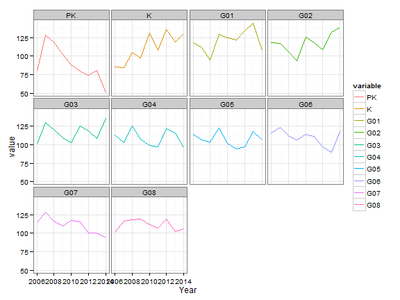

```r
dat_school = subset(dat, School_ID == 610135, select = c(Year, PK:G08))
dat_school = dat_school[order(dat_school$Year), ]

library(reshape2)
school_m = melt(dat_school, id = "Year")
ggplot(school_m, aes(Year, value, colour = variable)) + geom_line() + facet_wrap(~variable)
```

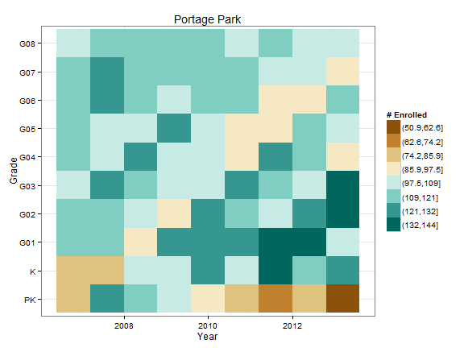

```r
ggplot(school_m, aes(Year, variable, fill = cut(value, 8))) + geom_tile() +
    scale_fill_brewer(type = "div", palette = 1) + labs(title = "Portage Park",
    y = "Grade", fill = "# Enrolled")
```

From the tile plot, you can see some trends of high and low enrollments following each year.